# Miami-Dade County COVID-19 Trajectory

Roy Williams, Gabriel J. Odom, Zoran Bursac, and Mary Jo Trepka

01 October 2020

# Introduction

Public understanding of science is critical in times of crisis. The following analysis was conducted to examine the trajectory of COVID-19 in Miami-Dade County. For phased reopening, the White House has set guidelines for local municipalities in their “Opening Up American Again” report. In the report, it is highly suggested that:

1. Local areas show a downward trajectory in the number of positive cases as a percent of total tests over a two-week period, and
2. Local hospitals have capacity to handle all patients without crisis care.

The analysis begins by looking at the number of new positive cases each day and the number of total tests performed each day. The figures are presented together because **as there is more testing, there are likely to be more positive test results**. Therefore, the proportion of positive cases is also calculated. Given either a flat or increasing number of tests performed, **the proportion of positive cases is the key metric to be used when looking at epidemic trajectory**. It is recommended that this proportion not exceed 5%.

Finally, to ensure hospitals can meet demand without crisis care, the COVID-19 positive hospitalization census, COVID-19 positive ICU census, and COVID-19 positive ventilation census is plotted over time. Census refers to the number of COVID-19 positive patients in the hospital, ICU, and on ventilators, respectively, on a given day. **Note: 5-day moving averages are used to smooth data.** **Note: On 8/31 there was a one-time historical data submission of a large number of cases from a large laboratory. The number of cases for 8/31 in the current report excludes this historical data submission.**

# COVID-19 Test Counts and Proportions

## Full Data

This is a table of the most recent data we have available. We include data sources at the end of the document.

| Date | Positive | Negative | Total | PropPositive |
| --- | --- | --- | --- | --- |
| 20-Mar | 23 | 146 | 169 | 13.6094675 |
| 21-Mar | 53 | 419 | 472 | 11.2288136 |
| 22-Mar | 83 | 452 | 535 | 15.5140187 |
| 23-Mar | 44 | 241 | 285 | 15.4385965 |
| 24-Mar | 90 | 491 | 581 | 15.4905336 |
| 25-Mar | 154 | 1079 | 1233 | 12.4898621 |
| 26-Mar | 178 | 749 | 927 | 19.2017260 |
| 27-Mar | 205 | 1066 | 1271 | 16.1290323 |
| 28-Mar | 270 | 917 | 1187 | 22.7464195 |
| 29-Mar | 362 | 1248 | 1610 | 22.4844720 |
| 30-Mar | 278 | 963 | 1241 | 22.4012893 |
| 31-Mar | 461 | 1613 | 2074 | 22.2275796 |
| 1-Apr | 272 | 1569 | 1841 | 14.7745790 |
| 2-Apr | 544 | 2413 | 2957 | 18.3970240 |
| 3-Apr | 625 | 1878 | 2503 | 24.9700360 |
| 4-Apr | 531 | 2521 | 3052 | 17.3984273 |
| 5-Apr | 311 | 1260 | 1571 | 19.7963081 |
| 6-Apr | 556 | 2309 | 2865 | 19.4066318 |
| 7-Apr | 493 | 1990 | 2483 | 19.8550141 |
| 8-Apr | 488 | 1113 | 1601 | 30.4809494 |
| 9-Apr | 435 | 2636 | 3071 | 14.1647672 |
| 10-Apr | 542 | 2505 | 3047 | 17.7879882 |
| 11-Apr | 563 | 2732 | 3295 | 17.0864947 |
| 12-Apr | 364 | 1614 | 1978 | 18.4024267 |
| 13-Apr | 477 | 2267 | 2744 | 17.3833819 |
| 14-Apr | 364 | 1663 | 2027 | 17.9575728 |
| 15-Apr | 438 | 2392 | 2830 | 15.4770318 |
| 16-Apr | 536 | 2767 | 3303 | 16.2276718 |
| 17-Apr | 519 | 2901 | 3420 | 15.1754386 |
| 18-Apr | 296 | 1509 | 1805 | 16.3988920 |

[output cut: 162 more lines]

## Total COVID-19 Tests by Day

We see the following pattern for the count of total tests. (shown on a log scale):

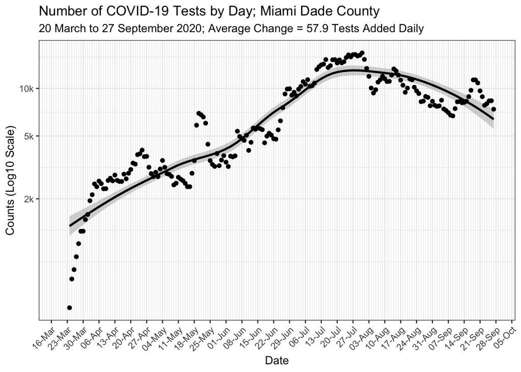

The average number of COVID-19 tests performed each day has increased from about 2,000 in early April to around 12,500 in August before declining to over 5,000 per day in September. On average, from 20 March until 27 September, there was an increase of approximately 58 addition tests performed each day over the previous day. This data is presented on a log scale. Over the past two weeks, there was a decrease of -10 fewer tests performed each day.

## Positive COVID-19 Tests by Day

We see the following pattern for the count of positive tests:

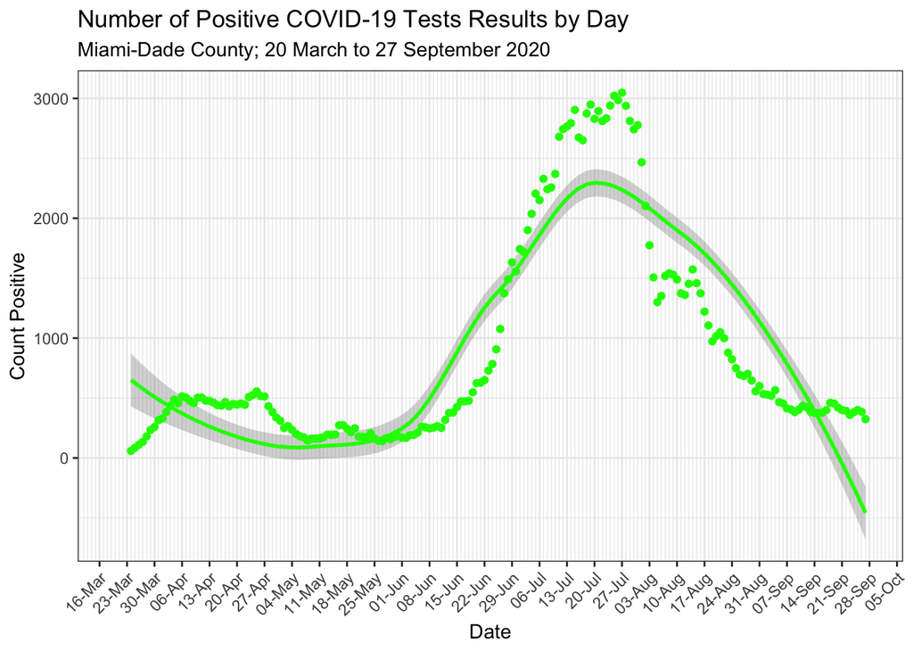

### Positive COVID-19 Tests within the Past Two Weeks

In addition to the overall trend of positive COVID-19 tests shown above, we also show an enhanced view of the last two weeks.

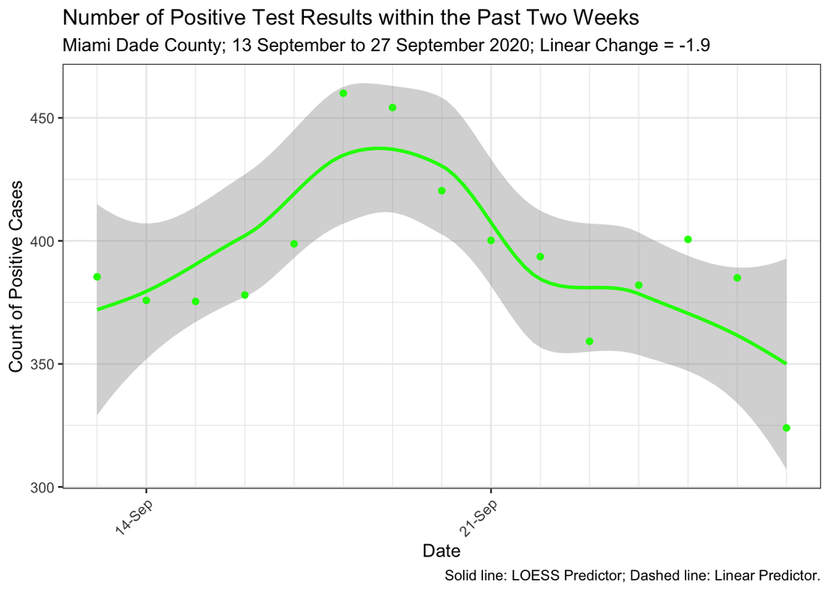

## Proportion of Positive Cases within Past Two Weeks

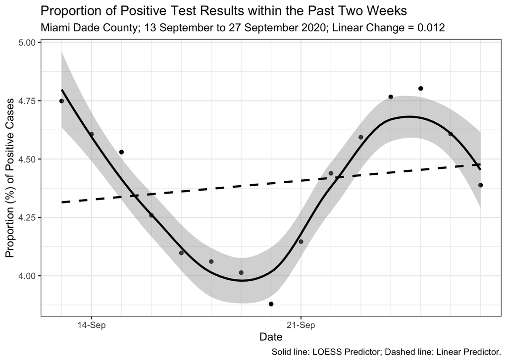

## Proportion of Positive COVID-19 Tests by Day

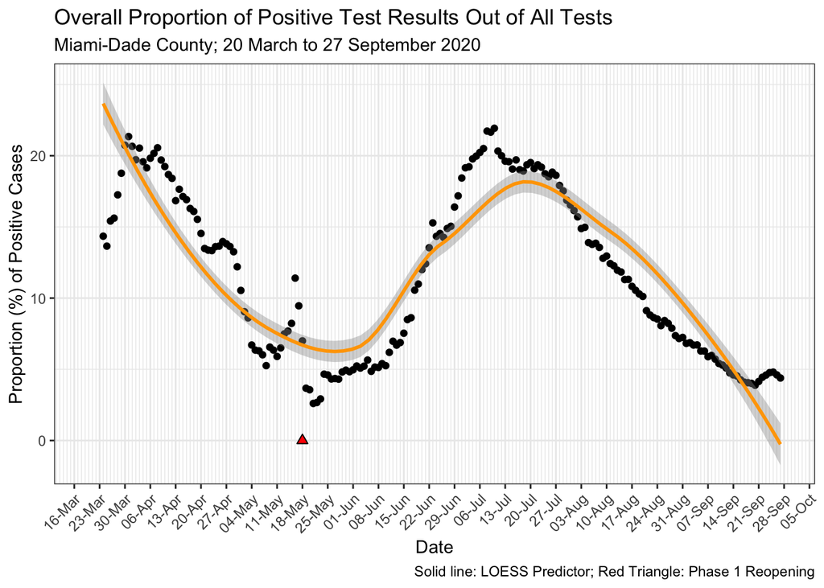

# Hospitalization Data

## Full Data

| Date | County | TotalBeds | AvailableBeds | HospitalCapacity | Hospitalized | ICU | Ventilated | AdmitPrevDay | DischPrevDay | DeltaAdmit |
| --- | --- | --- | --- | --- | --- | --- | --- | --- | --- | --- |
| 2020-04-02 | MIAMI-DADE | 9455 | NA | NA | 320 | 130 | 116 | NA | NA | NA |
| 2020-04-03 | MIAMI-DADE | 9455 | NA | NA | 346 | 133 | 116 | 111 | 33 | 78 |
| 2020-04-04 | MIAMI-DADE | 9455 | NA | NA | 416 | 133 | 112 | 59 | 37 | 22 |
| 2020-04-05 | MIAMI-DADE | 9455 | NA | NA | 533 | 188 | 146 | 108 | 19 | 89 |
| 2020-04-06 | MIAMI-DADE | 9455 | NA | NA | 516 | 178 | 151 | 89 | 21 | 68 |
| 2020-04-07 | MIAMI-DADE | 9455 | NA | NA | 591 | 199 | 167 | 76 | 28 | 48 |
| 2020-04-08 | MIAMI-DADE | 9455 | NA | NA | 636 | 215 | 166 | 107 | 32 | 75 |
| 2020-04-09 | MIAMI-DADE | 9455 | NA | NA | 634 | 232 | 170 | 99 | 61 | 38 |
| 2020-04-10 | MIAMI-DADE | 9455 | 4977 | 0.5263882 | 681 | 245 | 172 | 79 | 37 | 42 |
| 2020-04-10 | MIAMI-DADE | 9455 | NA | NA | 676 | 251 | 183 | 73 | 36 | 37 |
| 2020-04-11 | MIAMI-DADE | 9455 | NA | NA | 671 | 238 | 177 | 99 | 64 | 35 |
| 2020-04-12 | MIAMI-DADE | 9455 | NA | NA | 672 | 243 | 192 | 80 | 59 | 21 |
| 2020-04-12 | MIAMI-DADE | 9455 | NA | NA | 714 | 245 | 183 | 60 | 61 | -1 |
| 2020-04-13 | MIAMI-DADE | 9455 | NA | NA | 653 | 247 | 184 | 74 | 47 | 27 |
| 2020-04-13 | MIAMI-DADE | 9455 | NA | NA | 695 | 251 | 184 | 80 | 48 | 32 |
| 2020-04-14 | MIAMI-DADE | 9455 | 3264 | 0.3452142 | 653 | 204 | 146 | 69 | 41 | 28 |
| 2020-04-14 | MIAMI-DADE | 9455 | 3483 | 0.3683765 | 712 | 249 | 174 | 86 | 66 | 20 |
| 2020-04-15 | MIAMI-DADE | 9455 | 3325 | 0.3516658 | 693 | 234 | 169 | 84 | 76 | 8 |
| 2020-04-16 | MIAMI-DADE | 9455 | 3341 | 0.3533580 | 714 | 223 | 176 | 77 | 84 | -7 |
| 2020-04-16 | MIAMI-DADE | 9455 | 3604 | 0.3811740 | 736 | 226 | 176 | 74 | 111 | -37 |
| 2020-04-17 | MIAMI-DADE | 9455 | 3570 | 0.3775780 | 706 | 213 | 172 | 83 | 107 | -24 |
| 2020-04-17 | MIAMI-DADE | 9455 | 3471 | 0.3671074 | 797 | 285 | 170 | 74 | 88 | -14 |
| 2020-04-18 | MIAMI-DADE | 9455 | 3455 | 0.3654151 | 697 | 221 | 170 | 101 | 137 | -36 |
| 2020-04-18 | MIAMI-DADE | 9455 | 3561 | 0.3766261 | 697 | 219 | 170 | 93 | 138 | -45 |
| 2020-04-19 | MIAMI-DADE | 9455 | 3507 | 0.3709149 | 730 | 223 | 170 | 71 | 105 | -34 |
| 2020-04-20 | MIAMI-DADE | 9455 | 3410 | 0.3606557 | 727 | 210 | 167 | 58 | 64 | -6 |
| 2020-04-21 | MIAMI-DADE | 9455 | 3468 | 0.3667901 | 759 | 205 | 155 | 92 | 81 | 11 |
| 2020-04-22 | MIAMI-DADE | 9455 | 3260 | 0.3447911 | 743 | 196 | 148 | 72 | 88 | -16 |
| 2020-04-22 | MIAMI-DADE | 9455 | 3410 | 0.3606557 | 722 | 194 | 139 | 71 | 121 | -50 |
| 2020-04-23 | MIAMI-DADE | 9455 | 3378 | 0.3572713 | 706 | 186 | 129 | 91 | 62 | 29 |

[output cut: 158 more lines]

The data above is COVID-19 hospital census data in Miami-Dade County for all dates with available data since April 2. These columns are: the number of patients hospitalized with COVID-19 (**Hospitalized**), the number of patients in intensive care with COVID-19 (**ICU**), the number of patients in intensive care with COVID-19 who are also on ventilators (**Ventilated**), the number of patients positive for COVID-19 that were admitted the previous day (**AdmitPrevDay**), the number of patients recovered from COVID-19 that were discharged the previous day (**DischPrevDay**), and the net admission of patients positive for COVID-19 the previous day (**DeltaAdmit**; a negative value means more recovered patients were discharged than sick patients admitted). Not shown is the number of persons under investigation (PUI).*There is a data error for the count ventilated on the 4th of June. We removed this point from the data before estimating the models shown below.*

## Hospital COVID-19 Census

We now show a census plot of hospitalizations, patients in ICU, and those in ICU on ventilators (shown on a log scale):

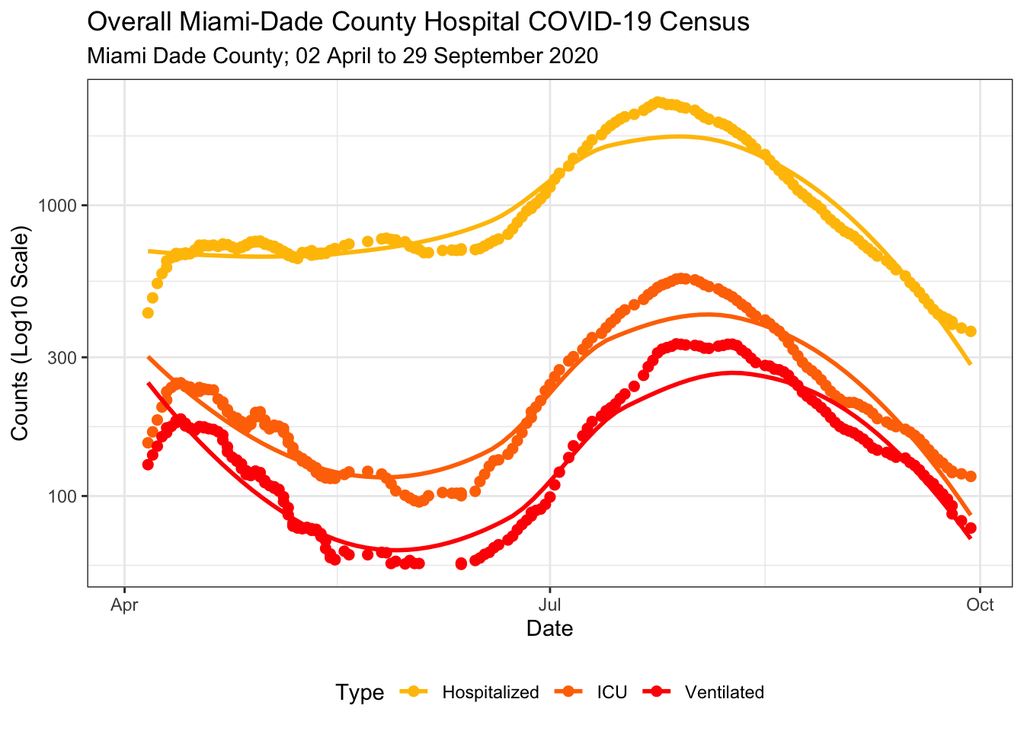

**Recently, on September 13th, there were 533 COVID positive patients hospitalized. This was a decrease from a high of 2299 obtained on July 21st. Additionally on September 13th, there were 169 COVID positive patients in the ICU. This was a decrease from from a high of 561 obtained on July 26th. Furthermore, on September 13th, there were 131 COVID positive patients ventilated. This was a decrease from a high of 335 obtained on July 24th. This represents a decreasing hospitalization burden** Note: data is plotted on a log scale.